# Does Airbnb have an impact on hotel room prices in Istanbul?

Yagmur Unsal

*METU Department of Economics*

January 2020

## About

The sharing economy is now playing a game-changing role in the accommodation industry. Airbnb, one of the largest sharing platforms for rental private properties, was founded in 2008, previously named AirBed & Breakfast. The company has emerged as an alternative to the traditional hotel industry by connecting the two-sided demands, people who are searching for cheap accommodation, and people who are renting their private rooms/homes. Since its foundation, Airbnb has experienced so much growth that it has more listings than any hotel group in the world (Farronato and Fradkin, 2018).

This disruptive innovation in the accommodation industry has significant implications on the traditional hotel industry since Airbnb offers additional attributes to travelers that do not exist in traditional accommodation options like a cozy place to stay, central location, or flexible booking. Even if the general opinion about the impact of Airbnb on the hotel industry is negative, that is the existence of Airbnb affects hotel sales’ performance or its price negatively, the researches made for different regions show that the effects are indeed more complicated than that. According to the research which analyzed the Airbnb’s impact on hotel sales growth for San Francisco, the impact of Airbnb differentiates according to the hotel segments (Blal, Singal, & Templin, 2018). The low-end and midscale segmented hotels are the ones which affected negatively and are in danger of being replaced by the offers of sharing platforms. On the other hand, the luxury and upper-scaled hotels are affected positively with the ‘enlarging the pie’ argument, which is increasing Airbnb supply is contributing to the traditional hotel industry. Besides, the impacts are altering according to the different customer segments. While Airbnb is used as a substitute for a hotel by a group of travelers, some are preferring to use Airbnb on purpose due to the cultural experience and local sights that Airbnb offers rather than traditional hotels. Several researches conducted on this subject reveal that the existence of Airbnb offerings harm the ability of hotels to increase their room prices during periods of peak demand due to its limited capacity in contrast with the flexible Airbnb supply. However, studies also declare that Airbnb has time and geographic heterogeneity (Zervas et al., 2017; Farronato and Fradkin, 2018). In other words, the effect of Airbnb on incumbent firms and consumers differs over time and by region.

In this research, we analyzed the existence of Airbnb on hotel room prices for Istanbul. Our primary assumption prior to this research is the negative effect of Airbnb on hotel prices; that is, the Airbnb supply decreases the hotel prices in Istanbul. There is a consistency between the results of our research and the researches conducted for other countries in this regard. While expecting a negative relationship between Airbnb supply and hotel prices prior to the research, the results showed us that this is not a one-way relationship. Aside from the fact that the results are more complex than a negative correlation, our regression analysis has been demonstrated that even in Istanbul, effects differ from region to region.

While conducting research, we used daily compiled Airbnb and hotel data for Istanbul. Therefore, we were unable to conduct a time-series analysis or a fully detailed report on the effect of Airbnb on accomodation industry for Istanbul. In order to analyze the trends over time or investigate the Airbnb effect on hotel sales’ performance, more detailed and long-term data is needed.

We conducted the research including the regression analyses by [RStudio](https://rstudio.com/) and built this website where we published the results along with the mappings and correlation/descriptive tables by R Markdown. The packages used throughout the process are as follows:

- [data.table](https://cran.r-project.org/web/packages/data.table/data.table.pdf)
- [leaflet](https://cran.r-project.org/web/packages/leaflet/leaflet.pdf)
- [ggplot2](https://ggplot2.tidyverse.org/)
- [kableExtra](https://cran.r-project.org/web/packages/kableExtra/kableExtra.pdf)
- [stargazer](https://cran.r-project.org/web/packages/stargazer/stargazer.pdf)

## Data

### Data Source

We collected data from three different sources. The Airbnb data came from insideairbnb.com, a website which provides scraped data on the property rental marketplace company Airbnb. The price, rating, latitude and longitude data of Airbnb listings are all available in their scraped data report. The hotel data came from two different sources: Name, number of rooms, zipcodes, latitude and longitude data of hotels are kindly provided by Delta Check, a global accommodation reference database; name, price and zipcode data of hotels in Istanbul is scraped from hotels.com. The two seperate hotel data is merged by hotel names and zipcodes. Afterwards, Airbnb data is merged with the hotel data by using the coordinates (latitude and longitude) of both.

Hotel Data:

- Delta Check (Global Accommodation Reference Database)
- [hotels.com](https://tr.hotels.com/)
- Hotels’ price data are compiled on 7 November 2019

Airbnb Data:

- [insideairbnb.com](http://insideairbnb.com/get-the-data.html)
- Downloaded on 8 December 2019
- Listings’ are compiled on November 2019

### Variables

Hotel variables:

- Price (in *turkish lira*)
- Number of rooms (proxy for “Hotel Size”)
- Longitude
- Latitude

Airbnb variables:

- Price (in *turkish lira*)
- Review scores rating
- Longitude
- Latitude

## Descriptives

Along with the variables (price, number of rooms, latitude and longitude) directly provided by the data sources for Airbnb and hotels, we also created Airbnb and hotel variables in order to use in regression analysis. These variables are as follows: Hotel supply represents the total number of hotels which are located within one kilometer distance of each hotel and the average number of rooms of these hotels is referred as ‘neighbouring hotel size’ which is used as a proxy for the hotel magnitude in the neighbourhood. By using the same technique, we also created Airbnb variables such as Airbnb supply which stands for the total number of Airbnb offerings located within one kilometer distance of each hotel and the average price and rating of these Airbnb listings, referred as Airbnb price and Airbnb rating respectively. The Airbnb and hotel variables along with their explanations can be found in the tables below.

Table A: Hotel variables in regression

| Legend | Variable |
| --- | --- |
| Hotel Size | Number of rooms in the hotel |
| Hotel Supply | Total number of rooms in hotels located within 1 km distance |
| Neighbouring Hotel Size | Average number of rooms in hotels located within 1 km distance |

Table B: Airbnb variables in regression

| Legend | Variable |
| --- | --- |
| Airbnb Supply | Total number of Airbnb offerings located within 1 km distance |
| Airbnb Price | Average price of Airbnb offerings located within 1 km distance |
| Airbnb Rating | Average rating of Airbnb offerings located within 1 km distance |

Prior to the regression analysis, in order to check whether there is significant relationship between hotels and Airbnb offerings in Istanbul, we draw the correlation graph of Airbnb and hotel supply. According to the graph below, there is significant correlation between Airbnb and hotel supply in Istanbul in some regions. When we analyze the source of this correlation, we found out that the characteristics of Airbnb and hotel supply differentiates in certain regions.

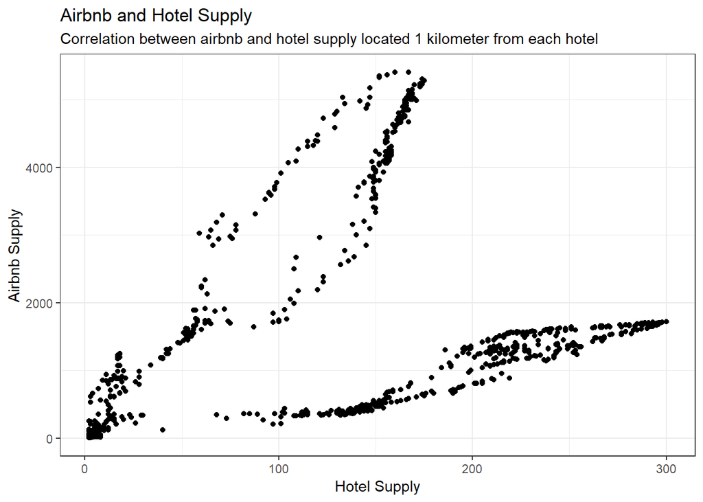

Due to the differentiation in the characteristics of Airbnb and hotel supply in certain regions, by setting Bosphorus and Halic bridge as the breakpoints, we created four regions in Istanbul to be used further in regression analysis. The region in which the hotels are colored with red and referred to as the “Old City” of Istanbul, which is known for its historical places. The northern side of Halic Bridge colored with green is known for its more luxurious and upper-segmented touristic places. The remaining two regions represent other parts of Europe, indicated by purple, and the entire Anatolian region, indicated by blue. While the Anatolian continent can be examined in a single region, three different results have been observed within the European continent.

[interactive chart not shown]

The correlation matrices and desctiptive tables below show the correlation between Airbnb variables and descriptives of each variable used in regression analysis according to the regions in Istanbul. There are 873 observations in total, that is the total number of hotels, for the inclusive Istanbul regression. Regarding the regional regressions, there are 64 observations in the Anatolian region, 421 observations in the Old City district, 68 and 319 for the rest of the European and the North of Halic region, respectively.

**Anatolian Region**

[interactive chart not shown]

Table 1a: Correlation between Airbnb variables for Anatolian region

|  | Airbnb Supply | Airbnb Price | Airbnb Rating |
| --- | --- | --- | --- |
| Airbnb Supply | 1.00 | -0.38 | -0.09 |
| Airbnb Price | -0.38 | 1.00 | 0.33 |
| Airbnb Rating | -0.09 | 0.33 | 1.00 |

Table 1b: Descriptives for Anatolian region

|  | Room price | Number of rooms | Hotel supply | Neighbouring hotel size | Airbnb supply | Airbnb Price | Airbnb Rating |
| --- | --- | --- | --- | --- | --- | --- | --- |
| min | 178.00 | 2.08 | 0.69 | 7.00 | 1.10 | 121.00 | 83.62 |
| max | 2599.00 | 5.83 | 2.89 | 320.00 | 7.13 | 857.00 | 100.00 |
| mean | 506.41 | 4.00 | 1.67 | 89.91 | 4.65 | 257.71 | 93.38 |
| std.dev | 434.96 | 1.09 | 0.75 | 59.13 | 1.61 | 137.51 | 3.29 |

**The Old City District**

[interactive chart not shown]

Table 2a: Correlation between Airbnb variables for Old City

|  | Airbnb Supply | Airbnb Price | Airbnb Rating |
| --- | --- | --- | --- |
| Airbnb Supply | 1.00 | 0.63 | -0.37 |
| Airbnb Price | 0.63 | 1.00 | -0.05 |
| Airbnb Rating | -0.37 | -0.05 | 1.00 |

Table 2b: Descriptives for Old City

|  | Room price | Number of rooms | Hotel supply | Neighbouring hotel size | Airbnb supply | Airbnb Price | Airbnb Rating |
| --- | --- | --- | --- | --- | --- | --- | --- |
| min | 133.00 | 1.61 | 1.10 | 15.00 | 4.83 | 236.90 | 86.37 |
| max | 6424.00 | 5.51 | 5.70 | 62.85 | 7.45 | 766.85 | 94.07 |
| mean | 696.85 | 3.35 | 5.18 | 36.17 | 6.75 | 568.02 | 88.02 |
| std.dev | 802.96 | 0.72 | 0.54 | 11.75 | 0.63 | 91.55 | 0.74 |

**The Rest of the European Region**

[interactive chart not shown]

Table 3a: Correlation between Airbnb variables for the rest of the European region

|  | Airbnb Supply | Airbnb Price | Airbnb Rating |
| --- | --- | --- | --- |
| Airbnb Supply | 1.00 | -0.48 | -0.04 |
| Airbnb Price | -0.48 | 1.00 | -0.17 |
| Airbnb Rating | -0.04 | -0.17 | 1.00 |

Table 3b: Descriptives for the rest of the European region

|  | Room price | Number of rooms | Hotel supply | Neighbouring hotel size | Airbnb supply | Airbnb Price | Airbnb Rating |
| --- | --- | --- | --- | --- | --- | --- | --- |
| min | 143.00 | 2.56 | 0.69 | 18.00 | 2.20 | 152.16 | 76.64 |
| max | 3304.00 | 6.03 | 2.48 | 330.00 | 5.06 | 1437.38 | 100.00 |
| mean | 483.31 | 4.45 | 1.67 | 126.57 | 3.78 | 375.66 | 87.94 |
| std.dev | 444.05 | 0.96 | 0.57 | 74.85 | 0.95 | 250.07 | 4.79 |

**The North of Halic**

[interactive chart not shown]

Table 4a: Correlation between Airbnb variables for the north of Halic

|  | Airbnb Supply | Airbnb Price | Airbnb Rating |
| --- | --- | --- | --- |
| Airbnb Supply | 1.00 | -0.05 | -0.34 |
| Airbnb Price | -0.05 | 1.00 | 0.15 |
| Airbnb Rating | -0.34 | 0.15 | 1.00 |

Table 4b: Descriptives for the north of Halic

|  | Room price | Number of rooms | Hotel supply | Neighbouring hotel size | Airbnb supply | Airbnb Price | Airbnb Rating |
| --- | --- | --- | --- | --- | --- | --- | --- |
| min | 127.00 | 1.39 | 0.69 | 12.50 | 2.71 | 179.02 | 84.32 |
| max | 6048.00 | 6.72 | 5.16 | 259.00 | 8.59 | 1047.64 | 97.92 |
| mean | 807.82 | 3.58 | 4.20 | 64.89 | 7.58 | 360.44 | 91.21 |
| std.dev | 1005.95 | 1.06 | 1.11 | 34.65 | 1.13 | 66.24 | 1.51 |

**Istanbul**

Table 5a: Correlation between Airbnb variables for Istanbul

|  | Airbnb Supply | Airbnb Price | Airbnb Rating |
| --- | --- | --- | --- |
| Airbnb Supply | 1.00 | 0.10 | -0.01 |
| Airbnb Price | 0.10 | 1.00 | -0.45 |
| Airbnb Rating | -0.01 | -0.45 | 1.00 |

Table 5b: Descriptives for Istanbul

|  | Room price | Number of rooms | Hotel supply | Neighbouring hotel size | Airbnb supply | Airbnb Price | Airbnb Rating |
| --- | --- | --- | --- | --- | --- | --- | --- |
| min | 127.00 | 1.39 | 0.69 | 7.00 | 1.10 | 121.00 | 76.64 |
| max | 6424.00 | 6.72 | 5.70 | 330.00 | 8.59 | 1437.38 | 100.00 |
| mean | 706.31 | 3.57 | 4.29 | 57.61 | 6.67 | 454.40 | 89.57 |
| std.dev | 847.97 | 0.96 | 1.44 | 43.28 | 1.47 | 156.88 | 2.65 |

## Model

We will estimate the model explaining room prices of the hotels in Istanbul. While our dependent variable is hotel room prices for one night, we use Airbnb supply, average price and rating of these Airbnb listings, number of rooms in each hotel, hotel supply, neighbouring hotel size and the interaction terms as the explanatory variables.

- Model 1

*log(room price) ~ log(airbnb supply) + log(number of rooms)*

- Model 2

*log(room price) ~ log(airbnb supply) + airbnb rating + airbnb price + log(number of rooms) + neighbouring hotel size*

- Model 3

*log(room price) ~ log(airbnb supply) + airbnb rating + airbnb price + log(number of rooms) + log(hotel supply) + log(airbnb supply)*log(number of rooms) + log(hotel supply)*log(number of rooms)*

### Anatolian Region

According to the regression results for the Anatolian region, the number of rooms has significant and positive effect on room prices. 10% increase in the number of rooms, a parameter that represents the hotel size, also increases room prices by 1.7%. That is, when the hotel size increases, its room price also increases by 1.7% for a 10% increase in the magnitude. However, the effect of Airbnb supply on room price is insignificant for the Anatolian region. When we include other Airbnb and hotel parameters, we can see that along with the number of rooms, Airbnb price also positively affects room price.

**Regression Results**

|  | *Dependent variable:* |  |  |
| --- | --- | --- | --- |
|  | Log(room price) |  |  |
|  | 1st model | 2nd model | 3rd model |
|  | (1) | (2) | (3) |
| Airbnb supply | -0.001 | 0.057 | -0.152 |
|  | (0.053) | (0.064) | (0.313) |
| Airbnb rating |  | 0.006 | 0.003 |
|  |  | (0.023) | (0.024) |
| Airbnb price |  | 0.001** | 0.001* |
|  |  | (0.001) | (0.001) |
| Number of rooms | 0.177** | 0.303*** | 0.050 |
|  | (0.079) | (0.095) | (0.301) |
| Neighbouring hotel size |  | -0.002 |  |
|  |  | (0.002) |  |
| Hotel supply |  |  | 0.214 |
|  |  |  | (0.514) |
| Airbnb supply*Number of rooms |  |  | 0.072 |
|  |  |  | (0.078) |
| Hotel supply*Number of rooms |  |  | -0.091 |
|  |  |  | (0.139) |
| Constant | 5.308*** | 3.759* | 4.777** |
|  | (0.496) | (2.092) | (2.380) |
| Observations | 64 | 64 | 64 |
| R<sup>2</sup> | 0.101 | 0.223 | 0.228 |
| Adjusted R<sup>2</sup> | 0.072 | 0.156 | 0.131 |
| Residual Std. Error | 0.583 (df = 61) | 0.556 (df = 58) | 0.564 (df = 56) |
| F Statistic | 3.441** (df = 2; 61) | 3.326** (df = 5; 58) | 2.357** (df = 7; 56) |
| *Note:* | p<0.1; p<0.05; p<0.01 |  |  |

### The Old City District

**Regression Results**

|  | *Dependent variable:* |  |  |
| --- | --- | --- | --- |
|  | Log(room price) |  |  |
|  | 1st model | 2nd model | 3rd model |
|  | (1) | (2) | (3) |
| Airbnb supply | 0.297*** | -0.025 | -0.841** |
|  | (0.057) | (0.110) | (0.409) |
| Airbnb rating |  | -0.042 | 0.099 |
|  |  | (0.061) | (0.065) |
| Airbnb price |  | 0.0002 | 0.001* |
|  |  | (0.001) | (0.001) |
| Number of rooms | 0.331*** | 0.409*** | -0.246 |
|  | (0.049) | (0.052) | (0.559) |
| Neighbouring hotel size |  | -0.023*** |  |
|  |  | (0.006) |  |
| Hotel supply |  |  | 1.035** |
|  |  |  | (0.437) |
| Airbnb supply*Number of rooms |  |  | 0.331*** |
|  |  |  | (0.118) |
| Hotel supply*Number of rooms |  |  | -0.317*** |
|  |  |  | (0.121) |
| Constant | 3.116*** | 9.456 | -3.857 |
|  | (0.474) | (6.069) | (6.673) |
| Observations | 421 | 421 | 421 |
| R<sup>2</sup> | 0.113 | 0.161 | 0.151 |
| Adjusted R<sup>2</sup> | 0.109 | 0.151 | 0.137 |
| Residual Std. Error | 0.673 (df = 418) | 0.657 (df = 415) | 0.662 (df = 413) |
| F Statistic | 26.581*** (df = 2; 418) | 15.950*** (df = 5; 415) | 10.506*** (df = 7; 413) |
| *Note:* | p<0.1; p<0.05; p<0.01 |  |  |

### The Rest of the European Region

**Regression Results**

|  | *Dependent variable:* |  |  |
| --- | --- | --- | --- |
|  | Log(room price) |  |  |
|  | 1st model | 2nd model | 3rd model |
|  | (1) | (2) | (3) |
| Airbnb supply | 0.153** | 0.233*** | 0.403 |
|  | (0.072) | (0.083) | (0.691) |
| Airbnb rating |  | 0.007 | 0.001 |
|  |  | (0.013) | (0.014) |
| Airbnb price |  | 0.0005* | 0.001* |
|  |  | (0.0003) | (0.0003) |
| Number of rooms | 0.333*** | 0.269*** | 0.304 |
|  | (0.071) | (0.099) | (0.318) |
| Neighbouring hotel size |  | 0.001 |  |
|  |  | (0.001) |  |
| Hotel supply |  |  | -0.450 |
|  |  |  | (1.127) |
| Airbnb supply*Number of rooms |  |  | -0.020 |
|  |  |  | (0.142) |
| Hotel supply*Number of rooms |  |  | 0.049 |
|  |  |  | (0.225) |
| Constant | 3.919*** | 3.008** | 3.590* |
|  | (0.502) | (1.400) | (1.941) |
| Observations | 68 | 68 | 68 |
| R<sup>2</sup> | 0.254 | 0.301 | 0.314 |
| Adjusted R<sup>2</sup> | 0.231 | 0.244 | 0.234 |
| Residual Std. Error | 0.501 (df = 65) | 0.496 (df = 62) | 0.500 (df = 60) |
| F Statistic | 11.062*** (df = 2; 65) | 5.332*** (df = 5; 62) | 3.919*** (df = 7; 60) |
| *Note:* | p<0.1; p<0.05; p<0.01 |  |  |

### The North of Halic

**Regression Results**

|  | *Dependent variable:* |  |  |
| --- | --- | --- | --- |
|  | Log(room price) |  |  |
|  | 1st model | 2nd model | 3rd model |
|  | (1) | (2) | (3) |
| Airbnb supply | 0.010 | 0.020 | -0.292 |
|  | (0.034) | (0.041) | (0.391) |
| Airbnb rating |  | 0.062** | 0.060** |
|  |  | (0.027) | (0.028) |
| Airbnb price |  | 0.001* | 0.001** |
|  |  | (0.001) | (0.001) |
| Number of rooms | 0.379*** | 0.399*** | -0.201 |
|  | (0.037) | (0.038) | (0.373) |
| Neighbouring hotel size |  | -0.001 |  |
|  |  | (0.001) |  |
| Hotel supply |  |  | 0.076 |
|  |  |  | (0.408) |
| Airbnb supply*Number of rooms |  |  | 0.093 |
|  |  |  | (0.100) |
| Hotel supply*Number of rooms |  |  | -0.024 |
|  |  |  | (0.101) |
| Constant | 4.874*** | -1.171 | 0.839 |
|  | (0.324) | (2.536) | (2.800) |
| Observations | 319 | 319 | 319 |
| R<sup>2</sup> | 0.266 | 0.291 | 0.301 |
| Adjusted R<sup>2</sup> | 0.262 | 0.279 | 0.285 |
| Residual Std. Error | 0.667 (df = 316) | 0.659 (df = 313) | 0.656 (df = 311) |
| F Statistic | 57.400*** (df = 2; 316) | 25.660*** (df = 5; 313) | 19.119*** (df = 7; 311) |
| *Note:* | p<0.1; p<0.05; p<0.01 |  |  |

### Istanbul

When we conduct the regressions by including all regions, that are all hotels and all Airbnb listings which are located within one kilometer distance in Istanbul, we can see that almost all parameters we included in the analysis are significant. These results are consistent with the region-based regression results of some regions while in contrast with others. In order to understand whether it is more accurate to a do region-based analysis or not, we did the log-likelihood ratio test. The likelihood ratio test showed us that we cannot pool the regions when we analyze the effects of Airbnb on hotel prices for Istanbul and we should estimate the regressions region by region.

**Regression Results**

|  | *Dependent variable:* |  |  |
| --- | --- | --- | --- |
|  | Log(room price) |  |  |
|  | 1st model | 2nd model | 3rd model |
|  | (1) | (2) | (3) |
| Airbnb supply | 0.127*** | 0.109*** | -0.176* |
|  | (0.017) | (0.019) | (0.098) |
| Airbnb rating |  | 0.034*** | 0.021* |
|  |  | (0.009) | (0.011) |
| Airbnb price |  | 0.001*** | 0.001*** |
|  |  | (0.0002) | (0.0002) |
| Number of rooms | 0.323*** | 0.366*** | -0.078 |
|  | (0.026) | (0.028) | (0.104) |
| Neighbouring hotel size |  | -0.001* |  |
|  |  | (0.001) |  |
| Hotel supply |  |  | 0.095 |
|  |  |  | (0.106) |
| Airbnb supply*Number of rooms |  |  | 0.094*** |
|  |  |  | (0.025) |
| Hotel supply*Number of rooms |  |  | -0.050* |
|  |  |  | (0.027) |
| Constant | 4.221*** | 0.726 | 3.402*** |
|  | (0.172) | (0.883) | (1.069) |
| Observations | 873 | 873 | 873 |
| R<sup>2</sup> | 0.160 | 0.204 | 0.219 |
| Adjusted R<sup>2</sup> | 0.158 | 0.199 | 0.213 |
| Residual Std. Error | 0.666 (df = 870) | 0.650 (df = 867) | 0.644 (df = 865) |
| F Statistic | 82.826*** (df = 2; 870) | 44.325*** (df = 5; 867) | 34.725*** (df = 7; 865) |
| *Note:* | p<0.1; p<0.05; p<0.01 |  |  |

## References

- [Blal, I., Singal, M., & Templin, J. (2018). Airbnb’s effect on hotel sales growth. International Journal of Hospitality Management, 73, 85-92.](https://journals.sagepub.com/doi/abs/10.1509/jmr.15.0204)
- [Farronato, C., & Fradkin, A. (2018). The welfare effects of peer entry in the accommodation market: The case of airbnb (No. w24361). National Bureau of Economic Research.](https://www.nber.org/papers/w24361)
- [Neeser, D., Peitz, M., & Stuhler, J. (2015). Does Airbnb hurt hotel business: Evidence from the Nordic countries. Universidad Carlos III de Madrid, 1-26.](https://www.researchgate.net/publication/282151529_Does_Airbnb_Hurt_Hotel_Business_Evidence_from_the_Nordic_Countries)
- [Zervas, G., Proserpio, D., & Byers, J. W. (2017). The rise of the sharing economy: Estimating the impact of Airbnb on the hotel industry. Journal of marketing research, 54(5), 687-705.](https://journals.sagepub.com/doi/abs/10.1509/jmr.15.0204)